## ACTIVIDAD GRUPAL: Boletín grupal sobre el efecto fotoeléctrico y partícula en campo magnético

# Fundamentos Físicos de la Informática

Grupo 18:

Lydia Logroño Ramas

Raul Garcia blanco

Marta Barberito de la Rocha

Diego Somovilla Arias

# Objetivo

Realizar de manera computacional dos ejercicios que recrean dos experimentos sobre física moderna: el movimiento de partículas cargadas en campos magnéticos y el efecto fotoeléctrico.

## Ejercicio de Calentamiento

$$ \frac{x\ -\ x_1}{x_2-x_1}\ =\frac{y\ -\ y_1}{y_2-y_1}\ $$

Donde $$ y_2-y_1 $$ se pasa al otro miembro multiplicando $$ \frac{\left(x\ -\ x_1\right)\left(y_2-y_1\right)}{x_2-x_1}\ =y-y_1\ $$

$$ y_1 $$

se pasa al otro miembro sumando $$ \frac{\left(x\ -\ x_1\right)\left(y_2-y_1\right)}{x_2-x_1}\ +y_1=y\ $$

se saca factor comun para poder operar $$ \frac{\left(x\ -\ x_1\right)\left(y_2-y_1\right)}{x_2-x_1}\ +\ \frac{y_1\ (x_2-x_1)}{x_2-x_1}=y\ $$

Se realizan las multiplicaciones $$ \frac{xy_2\ -\ xy_1\ {-\ x}_1y_2{\ +\ x}_1y_{1\ }{+\ x}_2y_1{-\ x}_1y_1}{x_2-x_1}\ =y\ $$

se simplifica $$ \frac{xy_2\ -\ xy_1\ -\ x_1y_2\ +\ x_2y_1}{x_2-x_1}\ =y\ $$

multiplicando numerador y denominador por -1

$$ \frac{-xy_{2\ }+\ xy_{1\ }+x_{1\ }y_{2\ }-\ x_2y_{1\ }}{{-x}_{2\ }+\ x_{1\ }}\ =\ y\ $$

reordenando las variables $$ \frac{\ xy_{1\ }-xy_{2\ }+x_{1\ }y_{2\ }-\ x_2y_{1\ }}{x_1-x_2}=y\ $$

Se saca factor comun $$ \frac{\ x(y_{1\ }-y_{2\ })+x_{1\ }y_{2\ }-\ x_2y_{1\ }}{x_1-x_2}=y\ $$

Como

$$ m=\frac{y_1-y_2}{x_1-x_2},    \ b=\frac{x_1\cdot y_2-x_2\cdot y_1}{x_1-x_2} $$

Tenemos que $$ y=m\cdot\ x+b $$

## ¿Qué hace CheepJ tras el telón y en qué estándares Web se basa?

Cheerpj es un compilador que permite convertir aplicaciones Java en JavaScript sin intervención manual. Consta de tres componentes: Un compilador de código de bytes de Java a JavaScript, así como de C/C++ a JavaScript. Los componentes en tiempo de ejecución que proporcionan la biblioteca Java y un módulo para la reflexión y generación dinámica de clases. Las API de interoperabilidad de CheerpJ que permiten el acceso y la manipulación del DOM desde Java, implementar los métodos Java nativos en JavaScript y el acceso a bibliotecas Java convertidas desde HTML5 / JavaScript.

El funcionamiento es el siguiente:

Compilar los archivos .jar a través del compilador CheerpJ AOT, elimina el código de bytes Java de los paquetes opcionalmente y se inserta la aplicación convertida o el enlace en caso de ser una biblioteca en una página HTML.

## Primer Ejercicio

Haced una tabla rápida con el nombre de cada color del arcoíris (azul, rojo, amarillo, etc.) en una columna, en una segunda columna escribe su longitud de onda (en metros) y en una tercera columna, su frecuencia (en Hercios). ¿Cuál es la relación matemática entre longitud de onda y frecuencia de una onda electromagnética?

En física, se conoce como longitud de onda a la distancia física entre dos puntos a partir de los cuales la onda se repite.

A la longitud de onda la nombramos con la letra landa (λ).

Las longitudes de onda para los 7 colores son las siguientes:

| Color | Longitud de onda Mínima | Longitud de onda Máxima |
| --- | --- | --- |
| Violeta | $${380\;{10^{-9}}}m$$ | $${427\;{10^{-9}}}m$$ |
| Azul | $${427\;{10^{-9}}}m$$ | $${475\;{10^{-9}}}m$$ |
| Cian | $${475\;{10^{-9}}}m$$ | $${497\;{10^{-9}}}m$$ |
| Verde | $${497\;{10^{-9}}}m$$ | $${570\;{10^{-9}}}m$$ |
| Amarillo | $${570\;{10^{-9}}}m$$ | $${590\;{10^{-9}}}m$$ |
| Naranja | $${590\;{10^{-9}}}m$$ | $${620\;{10^{-9}}}m$$ |
| Rojo | $${620\;{10^{-9}}}m$$ | $${760\;{10^{-9}}}m$$ |

¿Cuál es la relación matemática entre longitud de onda y frecuencia de una onda electromagnética?

Como bien hemos dicho antes la longitud de onda (λ) es la distancia física entre dos puntos a partir de los cuales la onda se repite. Y la frecuencia (f) es la medida del número de ciclos o repeticiones de la onda por unidad de tiempo.

La relación entre frecuencia y longitud de onda es que a mayor frecuencia, menor es la longitud de onda y cuando la frecuencia es menor, mayor es la longitud de onda.

Para calcular las frecuencias que corresponden a las longitudes de onda, utilizaremos las siguientes formulas: $$ f = \frac{v}{\lambda} $$

La velocidad de propagación de una onda (v), se puede medir como el tiempo que transcurre desde que es emitida hasta que se recibe.

Todas las ondas electromagnéticas se propagan en el vacío a una velocidad constante de 300.000.000 m/s, la velocidad de la luz (c), por lo que:

$$ v=c = 3 \; {10}^{8} $$

Podriamos escribir la formula para calcular la frecuencia como:

$$ f = \frac{3 \;{10}^{8}}{\lambda} $$

Calculando las frecuencias con esta ecuacion la tabla quedaria de la siguiente manera:

| Color | Longitud de onda Mínima | Longitud de onda Máxima | Frecuencia Mínima | Frecuencia Máxima |
| --- | --- | --- | --- | --- |
| Violeta | $$ { 380 \;{10^{-9}}}m $$ | $$ { 427 \;{10^{-9}}}m $$ | $$ { 7,89 \;{10^{14}}}Hz $$ | $$ { 7,03 \; {10^{14}}}Hz $$ |
| Azul | $$ { 427 \;{10^{-9}}}m $$ | $$ { 475 \;{10^{-9}}}m $$ | $$ { 7,03 \;{10^{14}}}Hz $$ | $$ { 6,32 \; {10^{14}}}Hz $$ |
| Cian | $$ { 475 \;{10^{-9}}}m $$ | $$ { 497 \;{10^{-9}}}m $$ | $$ { 6,32 \;{10^{14}}}Hz $$ | $$ { 6,04 \; {10^{14}}}Hz $$ |
| Verde | $$ { 497 \;{10^{-9}}}m $$ | $$ { 570 \;{10^{-9}}}m $$ | $$ { 6,04 \;{10^{14}}}Hz $$ | $$ { 5,26 \; {10^{14}}}Hz $$ |
| Amarillo | $$ { 570 \;{10^{-9}}}m $$ | $$ { 590 \;{10^{-9}}}m $$ | $$ { 5,26 \;{10^{14}}}Hz $$ | $$ { 5,08 \; {10^{14}}}Hz $$ |
| Naranja | $$ { 590 \;{10^{-9}}}m $$ | $$ { 620 \;{10^{-9}}}m $$ | $$ { 5,08 \;{10^{14}}}Hz $$ | $$ { 4,84 \; {10^{14}}}Hz $$ |
| Rojo | $$ { 620 \;{10^{-9}}}m $$ | $$ { 760 \;{10^{-9}}}m $$ | $$ { 4,84 \;{10^{14}}}Hz $$ | $$ { 3,95 \; {10^{14}}}Hz $$ |

## Toma de medidas con el applet del efecto Fotoeléctrico

Se simula para los materiales:

- Sodio

sin carga

con carga

potenciales de frenado (V)

120

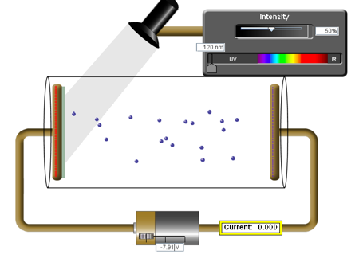

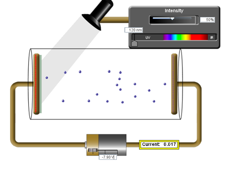

-7.91

250

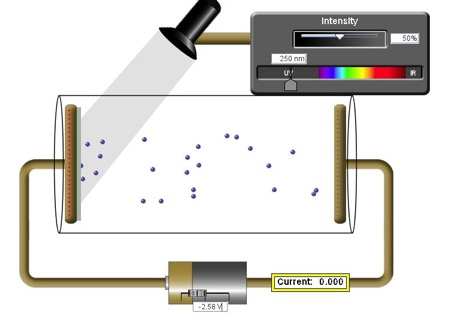

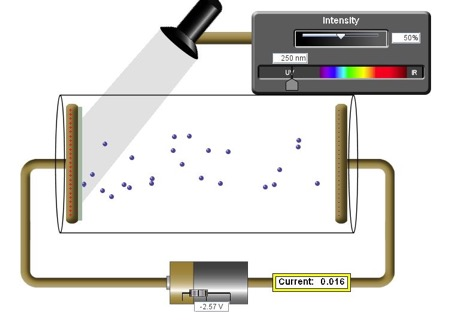

-2.58

400

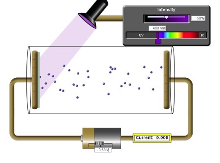

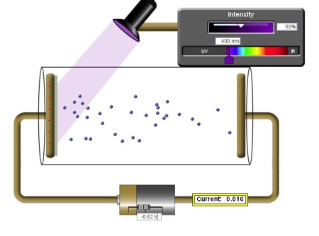

-0.63

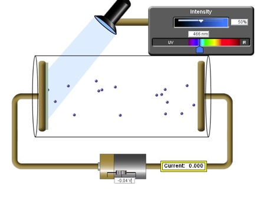

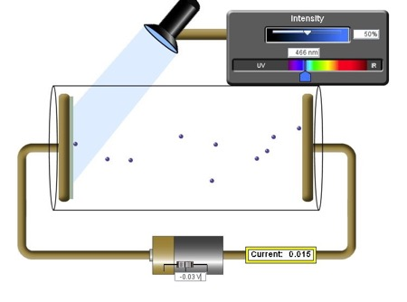

-0.04

- Zinc

Se comprueba que se produce carga para longitudes de onda entre 100 y 260 nm ,se toman los valores intermedios 150 y 200 nm

sin carga

con carga

potenciales de frenado (V)

100

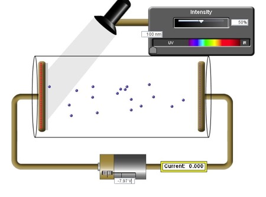

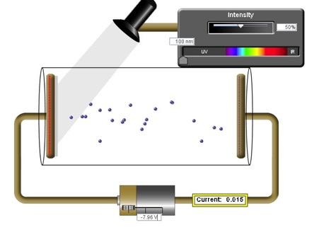

-7.97

150

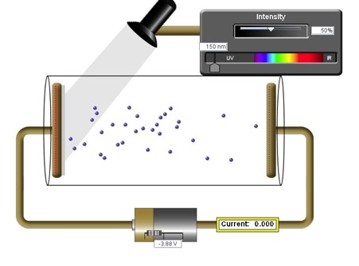

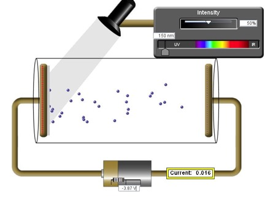

-3.88

200

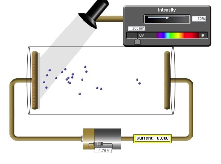

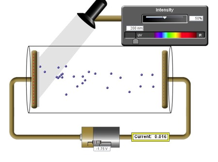

-1.76

260

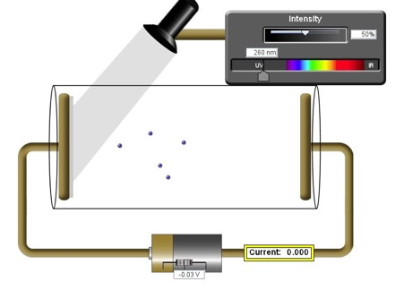

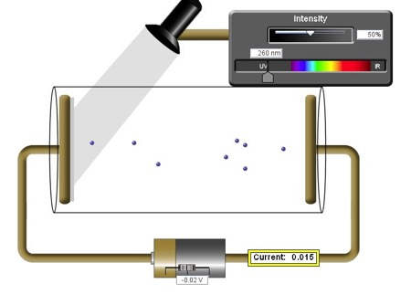

-0.03

- Cobre

Se comprueba que se produce carga para longitudes de onda entre 100 y 239 nm ,se toman los valores intermedios 150 y 200 nm

sin carga

con carga

potenciales de frenado (V)

100

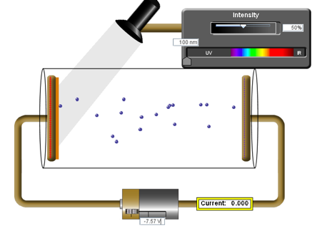

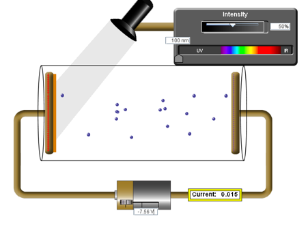

-7.57

150

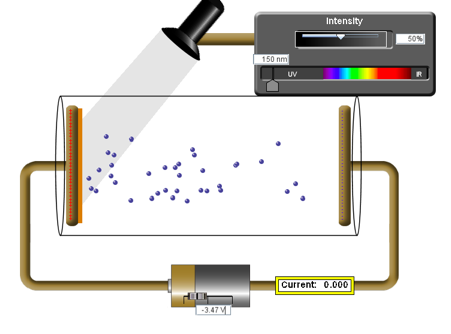

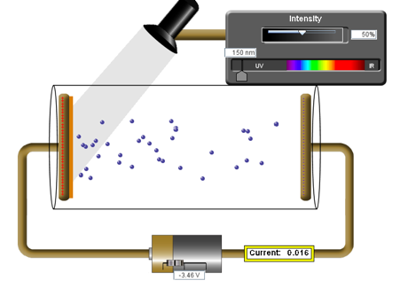

-3.47

200

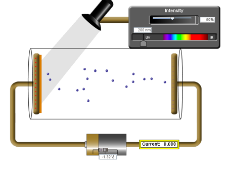

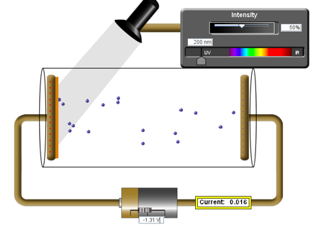

-1.32

239

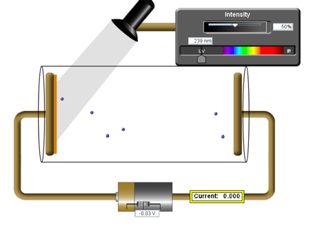

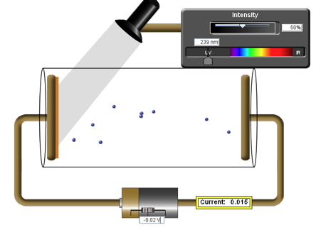

-0.03

- Platino

Se comprueba que se produce carga para longitudes de onda entre 100 y 181 nm ,se toman los valores intermedios 130 y 160 nm

sin carga

con carga

potenciales de frenado (V)

100

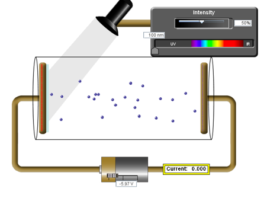

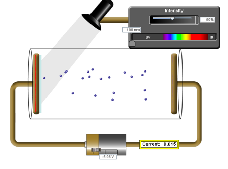

-5.97

130

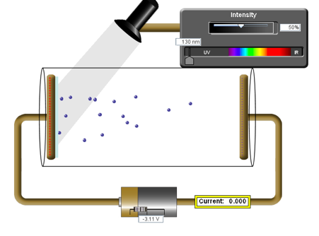

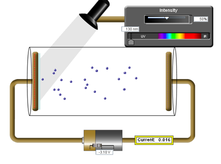

-3.11

160

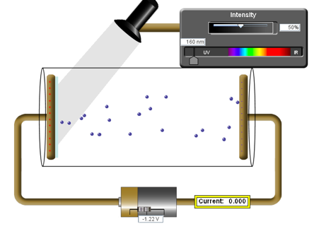

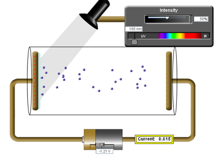

-1.22

181

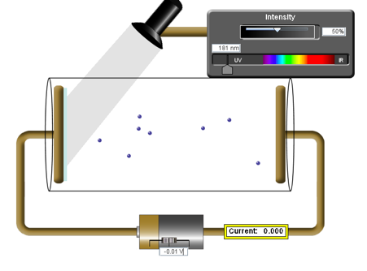

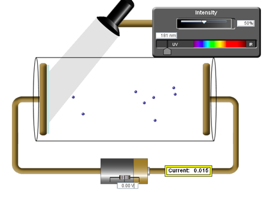

-0.01

- Calcio